# Encontro dos Saberes RESEX Cazumbá-Iracema (2022)

Análise mamíferos terrestres – 2014 a 2021

Elildo Carvalho Jr - ICMBio/CENAP

2022-03-31

## Apresentação

Este relatório apresenta resultados do Programa Monitora, Subprograma Terrestre, Componente Florestal Global, Alvo Mamíferos terrestres de médio e grande porte, protocolo básico, na **Reserva Extrativista Cazumbá-Iracema**, 2014 a 2021. O principal objetivo é subsidiar o Encontro dos Saberes que será realizado nesta unidade.

## Métodos

O protocolo básico para mamíferos utiliza o método de transecções lineares. Resumidamente, dois observadores percorrem as transecções a uma velocidade constante e registram, para cada avistamento de animais dos grupos-alvo, a espécie, o número de indivíduos e a distância perperndicular entre o primeiro indivíduo avistado e o centro da trilha. Cada UC deve ter pelo menos três transectos de 5 km e o esforço anual mínimo, combinando todos os transectos, deve ser de 150 km percorridos. A tabela 1 apresenta o esforço anual por trilha na RESEX Cazumbá-Iracema.

Tabela 1. Esforço de amostragem anual (em km) nas trilhas do ProgramaMonitora na RESEX Cazumbá-Iracema, 2014-2021

| EA | nome EA | 2014 | 2015 | 2016 | 2017 | 2018 | 2019 | 2020 | 2021 |
| --- | --- | --- | --- | --- | --- | --- | --- | --- | --- |
| 1 | Cazumba | 50 | 50 | 50 | 50 | 50 | 50 | 50 | 50 |
| 2 | Gamas | 50 | 50 | 50 | 50 | 50 | 50 | 50 | 50 |
| 3 | Alto Caeté | 50 | 50 | 50 | 50 | 50 | 50 | 50 | 50 |

## Número total de encontros

É importante lembrar que só porque uma espécie foi registrada poucas vezes, não quer dizer necessariamente que ela seja rara. Por exemplo, o protocolo não funciona bem para espécies noturnas como as antas e as pacas, pois as trilhas são percorridas durante o dia, quando essas espécies estão menos ativas. Além disso, espécies que são caçadas podem ficar muito ariscas, fugindo ao menor sinal da aproximação de pessoas.

Tabela 2. Numero de registros por especie obtidos pelo protocolo básicodo Programa Monitora na RESEX Cazumbá-Iracema, 2014-2021

| Ordem | Familia | Especie | Nome popular | Encontros | Individuos |
| --- | --- | --- | --- | --- | --- |
| Artiodactyla | Cervidae | Mazama americana | Veado-mateiro | 31 | 32 |
| Artiodactyla | Tayassuidae | Pecari tajacu | Caititu | 98 | 347 |
| Artiodactyla | Tayassuidae | Tayassu pecari | Queixada | 2 | 16 |
| Carnivora | Canidae | Speothos venaticus | Janauira | 1 | 1 |
| Carnivora | Felidae | Leopardus pardalis | Maracajá-açu | 1 | 1 |
| Carnivora | Felidae | Leopardus tigrinus | Gato-do-mato | 4 | 4 |
| Carnivora | Felidae | Leopardus wiedii | Maracajá-peludo | 3 | 4 |
| Carnivora | Felidae | Panthera onca | Onça-pintada | 3 | 3 |
| Carnivora | Felidae | Puma concolor | Onça-vermelha | 1 | 1 |
| Carnivora | Felidae | Puma yagouaroundi | Gato-mourisco | 1 | 1 |
| Carnivora | Mustelidae | Eira barbara | Irara | 18 | 26 |
| Carnivora | Mustelidae | Galictis vittata | Furão | 1 | 2 |
| Carnivora | Procyonidae | Nasua nasua | Quati | 26 | 168 |
| Cingulata | Dasypodidae | Cabassous unicinctus | Tatu-de-rabo-mole | 4 | 4 |
| Cingulata | Dasypodidae | Dasypus novemcinctus | Tatu-galinha | 2 | 2 |
| Cingulata | Dasypodidae | Priodontes maximus | Tatu-canastra | 2 | 6 |
| Perissodactyla | Tapiridae | Tapirus terrestris | Anta | 1 | 1 |
| Pilosa | Bradypodidae | Bradypus variegatus | Preguiça | 2 | 2 |
| Pilosa | Bradypodidae | Choloepus hoffmanni | Preguiça-real | 1 | 1 |
| Pilosa | Myrmecophagidae | Myrmecophaga tridactyla | Tamanduá-bandeira | 8 | 8 |
| Pilosa | Myrmecophagidae | Tamandua tetradactyla | Mambira | 14 | 14 |
| Rodentia | Dasyproctidae | Dasyprocta fuliginosa | Cutia | 158 | 181 |
| Rodentia | Dasyproctidae | Myoprocta pratti | Cutiara | 74 | 77 |
| Rodentia | Erethizontidae | Coendou bicolor | Quandú | 1 | 1 |
| Rodentia | Sciuridae | Sciuridae | Quatipuru | 230 | 286 |

A Figura 1 apresenta o número total de encontros para as espécies que tiveram pelo menos 5 encontros ao longo de todo o monitoramento. As espécies mais encontradas foram: quatipuru (família Sciuridae), cutia (*Dasyprocta fuliginosa*), caititu (*Pecari tajacu*), cutiara (*Myoprocta pratti*) e veado mateiro (*Mazama americana*). Os quatipurus incluem três espécies diferentes, que foram agrupadas nestas análises. As outras espécies foram encontradas poucas vezes.

Figura 1. Número total de encontros por espécie na RESEX Cazumbá-Iracema, 2014-2021. Somente espécies com mais de 5 encontros foram incluídas

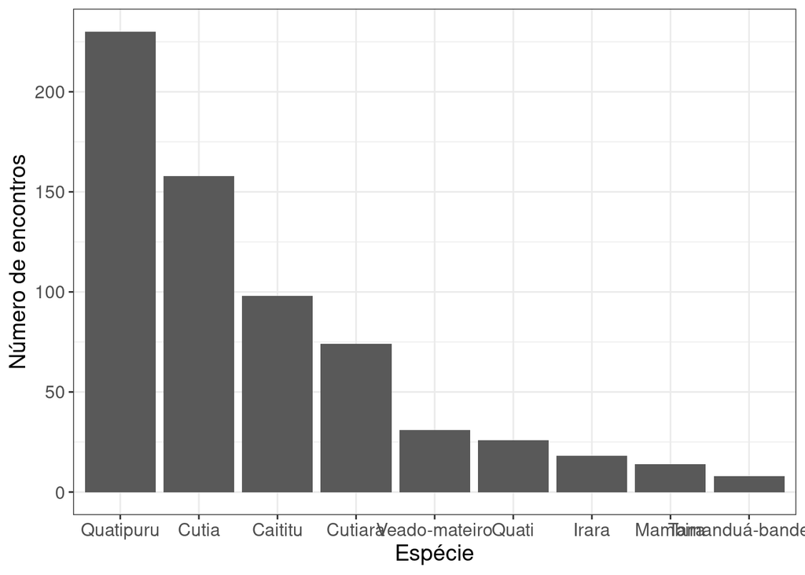

# Tendências populacionais

Nesta seção, incluímos somente as quatro espécies que apresentaram taxa de encontro anual média > 0.04 ind/km, o que equivale a um mínimo de um encontro a cada 25 km percorridos: quatipuru, cutia, caititu e cutiara (Tabela 3).

Tabela 3. Taxas de encontro anuais para as especies mais comuns demamíferos terrestres na RESEX Cazumbá-Iracema

| especie | 2014 | 2015 | 2016 | 2017 | 2018 | 2019 | 2020 | 2021 | média |
| --- | --- | --- | --- | --- | --- | --- | --- | --- | --- |
| Sciuridae | 0.25 | 0.19 | 0.28 | 0.20 | 0.25 | 0.25 | 0.05 | 0.06 | 0.192 |
| Dasyprocta fuliginosa | 0.15 | 0.15 | 0.15 | 0.06 | 0.11 | 0.14 | 0.15 | 0.14 | 0.132 |
| Pecari tajacu | 0.11 | 0.09 | 0.07 | 0.07 | 0.12 | 0.07 | 0.07 | 0.07 | 0.082 |
| Myoprocta pratti | 0.05 | 0.08 | 0.09 | 0.04 | 0.05 | 0.04 | 0.11 | 0.04 | 0.062 |

Figura 2. Taxa de encontro anual para quatipuru na RESEX Cazumbá-Iracema, 2014-2021

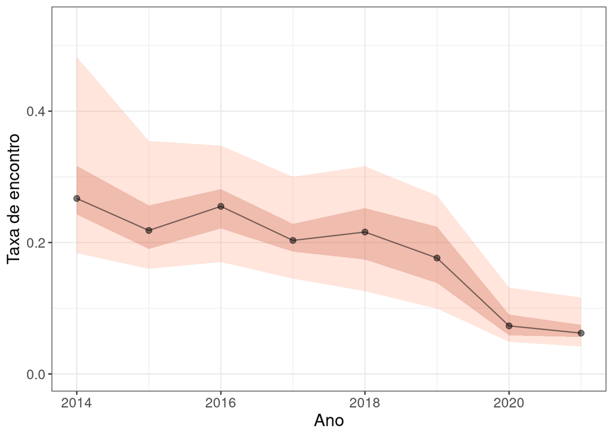

Figura 2. Taxa de encontro anual para cutia na RESEX Cazumbá-Iracema, 2014-2021

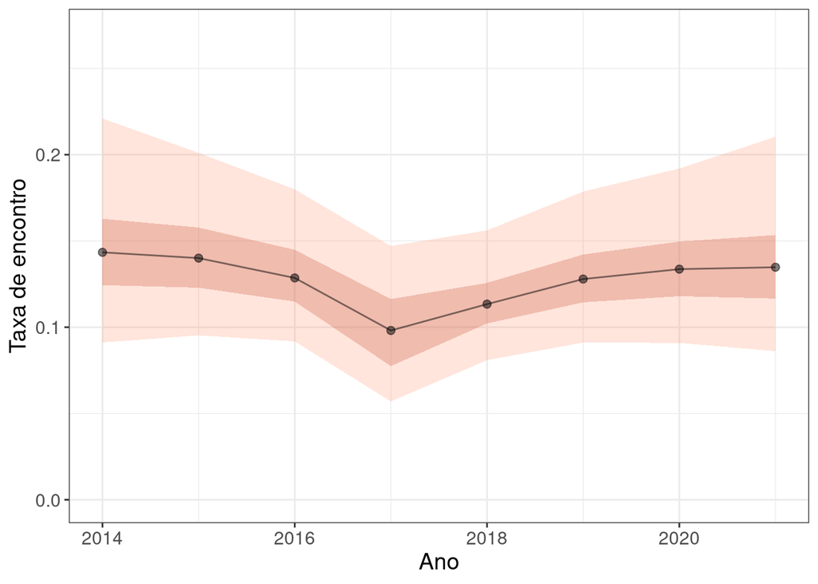

Figura 2. Taxa de encontro anual para cutiara na RESEX Cazumbá-Iracema, 2014-2021

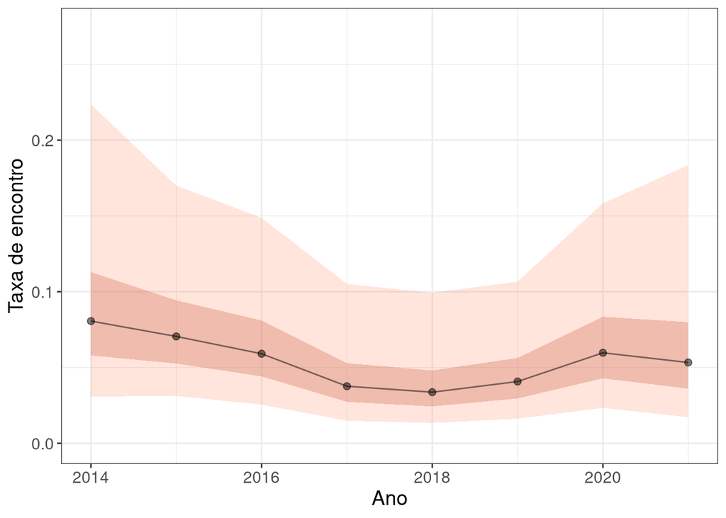

Figura 2. Taxa de encontro anual para caititu na RESEX Cazumbá-Iracema, 2014-2021

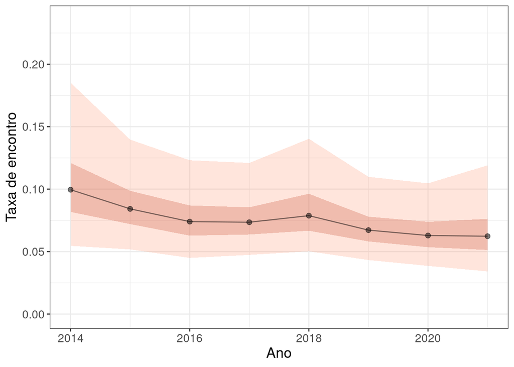

# Tendências populacionais por trilha

Figura 3. Taxa de encontro anual para quatipuru por trilha na RESEX Cazumbá-Iracema, 2014-2021

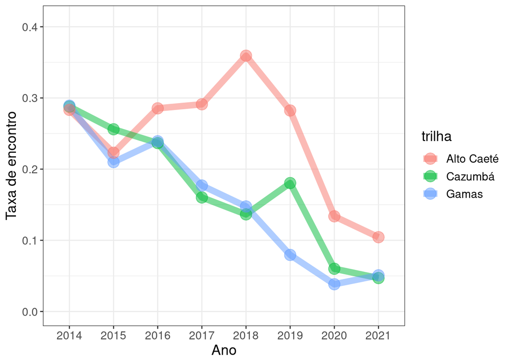

Figura 3. Taxa de encontro anual para cutia por trilha na RESEX Cazumbá-Iracema, 2014-2021

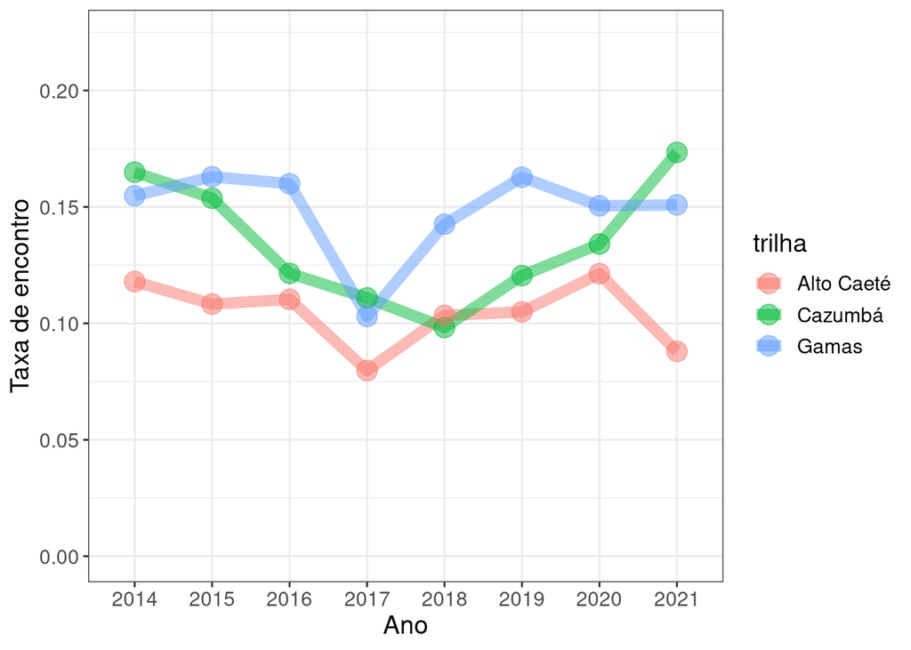

Figura 3. Taxa de encontro anual para cutiara por trilha na RESEX Cazumbá-Iracema, 2014-2021

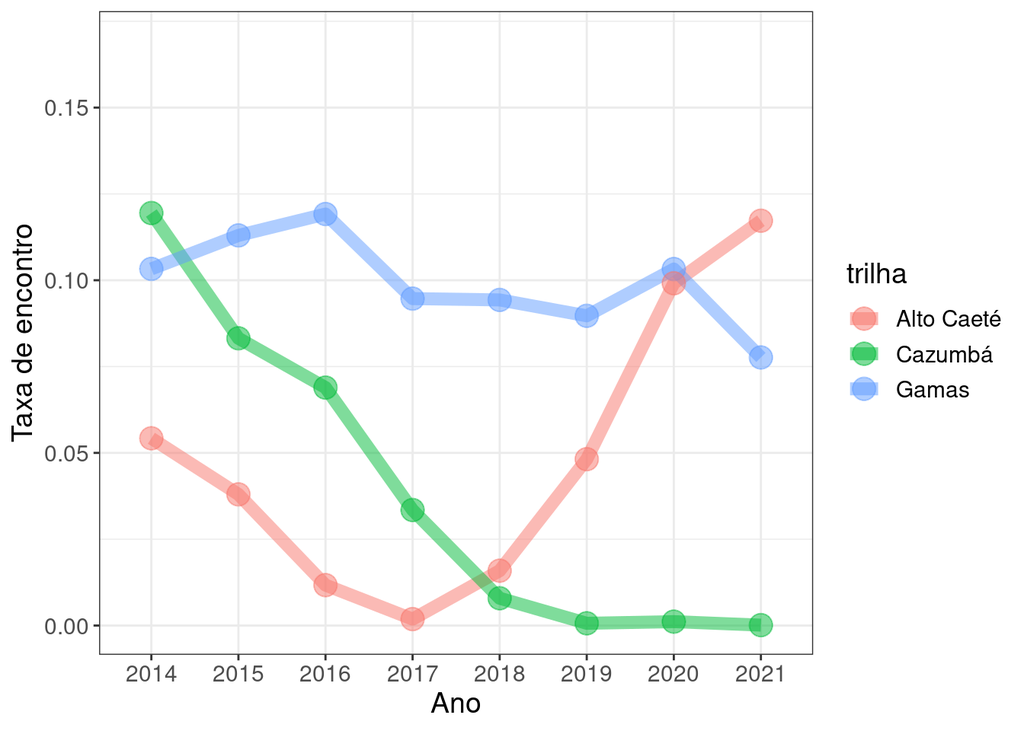

Figura 3. Taxa de encontro anual para caititu por trilha na RESEX Cazumbá-Iracema, 2014-2021

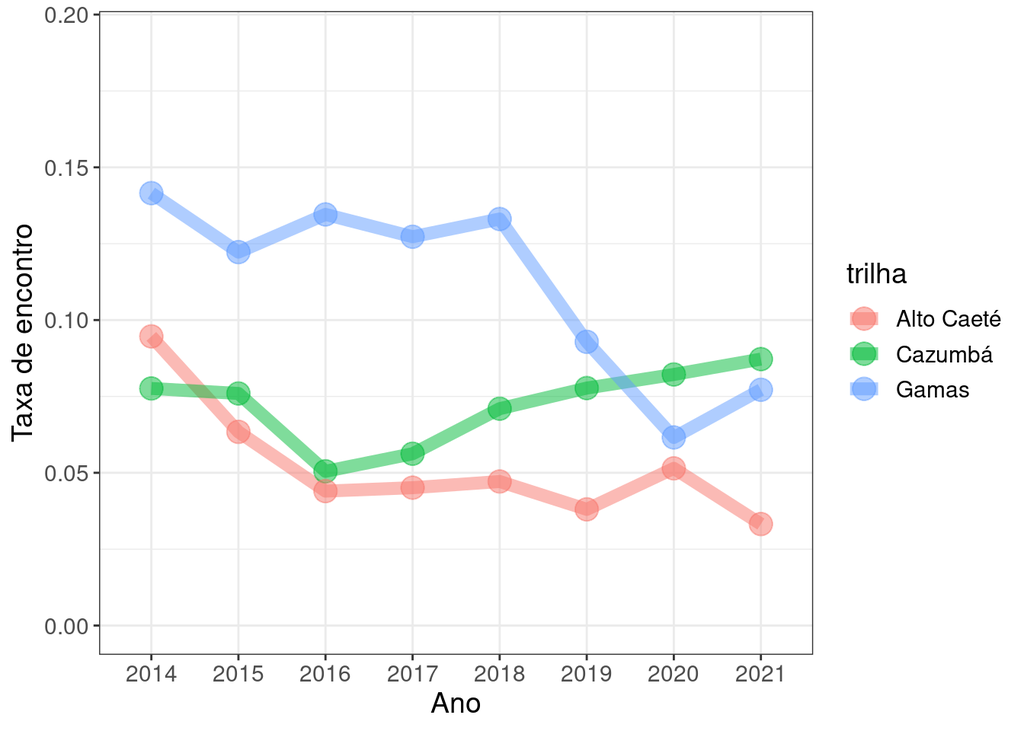

# Perguntas e reflexões

O que está acontecendo com os quatipurus? Eles estão realmente declinando, ou as pessoas estão registrando menos por ser uma espécie pequena, que não é caçada etc.?

De forma geral, a população de cutias parece estar estável. No entanto, elas sofreram um tombo em 2017. O que aconteceu nesse ano? Houve algum evento incomum, como uma seca mais forte ou algum desequilíbrio ambiental?

A cutiara também parece ter sofrido uma queda entre 2015 e 2017, mas não foi um tombo tão forte como o da cutia. O que será que aconteceu?

O caititu parece estar estável… ou está declinando bem devagar ao longo dos anos? Somente com mais anos de monitoramento poderemos saber.

Porque as tendências populacionais variaram tanto entre as trilhas?

Porque é importante monitorar várias trilhas ao invés de apenas uma?